# ASC_TIMEcourse_limma_nucleolus_analysis

Sarah Hp

6/4/22

Calculate time effect for adipose stem cell differentiation to adipocytes via RNAseq. Here we extract the differentially expressed genes for Pro - D0, D0 - D3 and D3 - D15 for two donors. Previously Pro, D0, D1, D3, and D9 were sequenced in triplicate for two independent donors (GSE176020). New samples: day15 floating and bulk RNAseq.

output files:

- adipogenesis_rpkm_tmm.tab
- adipogenesis_rpkm_tmm_means.tab
- nucleolus_adipogenesis_DE.tab

intermediate files (merge of serveral experiments):

- late_adipo_and_D1&D2_native_rnaseq.counts
- late_adipo_and_D1&D2_native_rnaseq_info.tab

```r
#DE tools
library(limma)
library(edgeR)
library(biomaRt) #annotation
#plotting
library(ggplot2)
library(RUVSeq)
#Data manipulation
library(tidyr)
library(dplyr)
```

```r
read.geo <- function(file_url) {
  con <- gzcon(url(file_url))
  txt <- readLines(con)
  return(read.delim(textConnection(txt), skip=1, header=T))
}
```

# Merge experiments

Skip ahead to `Start analysis here` for DGE analysis from intermediate files.

## Load Donor 2 timecourse from GEO

(with fractionally assigned multimapping alignments). Then format the table.

```r
d2_file = "https://www.ncbi.nlm.nih.gov/geo/download/?acc=GSE176020&format=file&file=GSE176020%5Fd13%5Frnaseq%2Emultim%2Ecounts%2Etxt%2Egz"
d2_tab = read.geo(d2_file)
colnames(d2_tab) =  gsub("output.01hisat.","", gsub(".sorted.bam","",colnames(d2_tab)))
#head(d2_tab) #table is messy so I won't print it here
```

Load file with sample info and match sample information to columns in FC table

```r
d2_info = read.delim("../sample_info/donor2_info.csv", header=TRUE, stringsAsFactors = FALSE, sep = ",")
#head(d2_info)

#remove unnecessary columns from d2_info
names(d2_info)[names(d2_info)=='Additional..fill.in.2.3.digits.code..max.5..construct.etc..'] = 'donor'
names(d2_info)[names(d2_info)=='Replicate..fill.in.number.'] = 'biorep'
names(d2_info)[names(d2_info)=='timept'] = 'time'
d2_info = d2_info[c('sample_id','time','donor','biorep','Tube.Label')]

#Checked that FC table and d2_info are in the same order
#colnames(d2_tab)
#d2_info$sample_id
```

## Load the Donor 1 timecourse:

And generate sample information from the bam file names

```r
d1_file = "https://www.ncbi.nlm.nih.gov/geo/download/?acc=GSE176020&format=file&file=GSE176020%5Fmar19%5Frnaseq%2Emultim%2Ecounts%2Etxt%2Egz"
d1_tab = read.geo(d1_file)
colnames(d1_tab) =  gsub("output.01hisat.","", gsub(".sorted.bam","",colnames(d1_tab)))
head(d1_tab)
```

```
##            Geneid                   Chr
## 1 ENSG00000223972     1;1;1;1;1;1;1;1;1
## 2 ENSG00000227232 1;1;1;1;1;1;1;1;1;1;1
## 3 ENSG00000278267                     1
## 4 ENSG00000243485             1;1;1;1;1
## 5 ENSG00000284332                     1
## 6 ENSG00000237613             1;1;1;1;1
##                                                               Start
## 1             11869;12010;12179;12613;12613;12975;13221;13221;13453
## 2 14404;15005;15796;16607;16858;17233;17606;17915;18268;24738;29534
## 3                                                             17369
## 4                                     29554;30267;30564;30976;30976
## 5                                                             30366
## 6                                     34554;35245;35277;35721;35721
##                                                                 End
```

[output cut: 27 more lines]

```r
#Remove the file system artefacts from the count column names to create a list of the libraries:
sample_id = grep("[[:digit:]]",colnames(d1_tab), value = T)
sample_id
```

```
##  [1] "1.KD4NT_S1"   "10.P6D3_S10"  "11.P6D9_S11"  "12.KD3NT_S12" "13.P8D0_S13"
##  [6] "14.P8D1_S14"  "15.P8D3_S15"  "16.P8D9_S16"  "2.KD5NT_S2"   "3.P5D0_S3"
## [11] "4.P5D1_S4"    "5.P5D3_S5"    "6.P5D9_S6"    "7.KD6NT_S7"   "8.P6D0_S8"
## [16] "9.P6D1_S9"
```

```r
#Next create a sample table with information about samples and time points taken from the filenames.
Tube.Label = gsub("\\..*_S[[:digit:]]+", "", sample_id)
time = gsub(".*(KD|P)[43586]D?", "", gsub("_S.*","",sample_id))
time = factor(gsub("NT","-2",time)) #match factors
biorep = gsub(".*\\.(KD|P)", "P", gsub("(D[0139]|NT)_S.*","",sample_id))
biorep =gsub("P3","P8",biorep) #fix biorep error
donor = rep("D1G", 16)

d1_info = data.frame(sample_id,time,donor,biorep,Tube.Label)
d1_info
```

```
##       sample_id time donor biorep Tube.Label
## 1    1.KD4NT_S1   -2   D1G     P4          1
## 2   10.P6D3_S10    3   D1G     P6         10
## 3   11.P6D9_S11    9   D1G     P6         11
## 4  12.KD3NT_S12   -2   D1G     P8         12
## 5   13.P8D0_S13    0   D1G     P8         13
## 6   14.P8D1_S14    1   D1G     P8         14
## 7   15.P8D3_S15    3   D1G     P8         15
## 8   16.P8D9_S16    9   D1G     P8         16
## 9    2.KD5NT_S2   -2   D1G     P5          2
## 10    3.P5D0_S3    0   D1G     P5          3
## 11    4.P5D1_S4    1   D1G     P5          4
## 12    5.P5D3_S5    3   D1G     P5          5
## 13    6.P5D9_S6    9   D1G     P5          6
## 14   7.KD6NT_S7   -2   D1G     P6          7
## 15    8.P6D0_S8    0   D1G     P6          8
## 16    9.P6D1_S9    1   D1G     P6          9
```

## Load New Samples (day 15)

These are from the same donors

```r
day15_tab = read.delim("../02featureCounts/day15_bulk_v_float.counts", skip=1,header=T, stringsAsFactors = F)
colnames(day15_tab) = gsub("output.01hisat.","", gsub(".sorted.bam","",colnames(day15_tab)))
colnames(day15_tab)
```

```
##  [1] "Geneid"       "Chr"          "Start"        "End"          "Strand"
##  [6] "Length"       "13.21417_S53" "14.21418_S2"  "15.21419_S9"  "16.21420_S16"
## [11] "17.21421_S24" "18.21422_S32" "19.21423_S40" "20.21424_S47" "21.21425_S54"
## [16] "22.21426_S3"  "23.21427_S10" "24.21428_S17"
```

```r
day15_info = read.delim("../sample_info/day15_bulk_v_float_info.csv", header=T, sep=",")
day15_info$sample_id = gsub("-",".", day15_info$sample_id)
day15_info$time = factor(gsub("D","", day15_info$time))
colnames(day15_info) = gsub("rep", "biorep", colnames(day15_info))
#use cell_type column as experiment delimiter
day15_info$exp = 3

day15_info = day15_info[!(colnames(day15_info) %in% c("bio.condition"))]

colnames(day15_info); day15_info$sample_id
```

```
## [1] "time"       "biorep"     "donor"      "separation" "sample_id"
## [6] "exp"
```

```
##  [1] "13.21417_S53" "14.21418_S2"  "15.21419_S9"  "16.21420_S16" "17.21421_S24"
##  [6] "18.21422_S32" "19.21423_S40" "20.21424_S47" "21.21425_S54" "22.21426_S3"
## [11] "23.21427_S10" "24.21428_S17"
```

Edits to day15 file to fit: - remove D from time; add dash to donor - change column names: rep to biorep; cell_type to exp - remove researcher, bio.condition

## Merge read counts and sample info

Merging the fc tables directly. Merge sample information for d1 and d2; remove tube.label column, add exp column (since d1 and d2 have overlapping samples) and add separaion = bulk for these experiments.

```r
early = merge(d2_tab, d1_tab)
colnames(early); dim(early)
```

```
##  [1] "Geneid"           "Chr"              "Start"            "End"
##  [5] "Strand"           "Length"           "6.19190_S20"      "7.19191_S1"
##  [9] "8.19192_S3"       "9.19193_S6"       "10.19194_S9"      "11.19195_S12"
## [13] "12.19196_S15"     "13.19197_S18"     "14.19198_S21"     "15.19199_S2"
## [17] "1.19200_S5"       "2.19201_S8"       "3.19202_S11"      "4.19203_S14"
## [21] "5.19204_S17"      "20.S2.KD5NT_S16"  "21.S7.KD6NT_S19"  "22.S12.KD3NT_S22"
## [25] "1.KD4NT_S1"       "10.P6D3_S10"      "11.P6D9_S11"      "12.KD3NT_S12"
## [29] "13.P8D0_S13"      "14.P8D1_S14"      "15.P8D3_S15"      "16.P8D9_S16"
## [33] "2.KD5NT_S2"       "3.P5D0_S3"        "4.P5D1_S4"        "5.P5D3_S5"
## [37] "6.P5D9_S6"        "7.KD6NT_S7"       "8.P6D0_S8"        "9.P6D1_S9"
```

```
## [1] 58735    40
```

```r
#Add experiment separator
d2_info$exp = 2
d1_info$exp = 1
colnames(d2_info)
```

```
## [1] "sample_id"  "time"       "donor"      "biorep"     "Tube.Label"
## [6] "exp"
```

```r
colnames(d1_info)
```

```
## [1] "sample_id"  "time"       "donor"      "biorep"     "Tube.Label"
## [6] "exp"
```

```r
early_info = rbind(d2_info, d1_info)
early_info$separation = "bulk"

early_info = early_info[colnames(early_info) != "Tube.Label"]

table(paste(early_info$time, early_info$donor, early_info$exp))
```

```
##
## -2 D1G 1 -2 D1G 2 -2 D2A 2  0 D1G 1  0 D2A 2  1 D1G 1  1 D2A 2  3 D1G 1
##        4        3        3        3        3        3        3        3
##  3 D2A 2  9 D1G 1  9 D2A 2
##        3        3        3
```

Merging in day15 now

```r
whole = merge(early, day15_tab)
dim(whole)
```

```
## [1] 58735    52
```

```r
whole_info = rbind(early_info, day15_info)
str(whole_info); tail(whole_info)
```

```
## 'data.frame':    46 obs. of  6 variables:
##  $ sample_id : chr  "6.19190_S20" "7.19191_S1" "8.19192_S3" "9.19193_S6" ...
##  $ time      : chr  "-2" "0" "1" "3" ...
##  $ donor     : chr  "D2A" "D2A" "D2A" "D2A" ...
##  $ biorep    : chr  "7" "7" "7" "7" ...
##  $ exp       : num  2 2 2 2 2 2 2 2 2 2 ...
##  $ separation: chr  "bulk" "bulk" "bulk" "bulk" ...
```

```
##       sample_id time donor biorep exp separation
## 41 19.21423_S40   15   D1G     P7   3       bulk
## 42 20.21424_S47   15   D1G   P8_2   3       bulk
## 43 21.21425_S54   15   D1G   P8_1   3       bulk
## 44  22.21426_S3   15   D2A     P7   3       bulk
## 45 23.21427_S10   15   D2A     P6   3       bulk
## 46 24.21428_S17   15   D2A     P7   3       bulk
```

Save combined read counts so we don’t need to do this again.

```r
write.table(whole, "../03limma/late_adipo_and_D1&D2_native_rnaseq.counts", sep="\t", row.names = F)
write.table(whole_info, "../03limma/late_adipo_and_D1&D2_native_rnaseq_info.tab", sep="\t", row.names = F)
```

# Start Analysis Here

Load combined read counts from above

```r
whole = read.delim("../03limma/late_adipo_and_D1&D2_native_rnaseq.counts", sep="\t", check.names = F )
whole_info = read.delim( "../03limma/late_adipo_and_D1&D2_native_rnaseq_info.tab", sep="\t")
```

## Make DGE object

remove additional samples.

```r
whole_info$time.donor = paste(whole_info$time, whole_info$donor, sep=".")
whole_info$group = paste(whole_info$time.donor, whole_info$separation, sep=".")

whole_ob = DGEList(counts=data.matrix(whole[grep("[[:digit:]]", colnames(whole))]),
                   genes= whole[c("Geneid", "Length")], samples = whole_info)
rownames(whole_ob$counts) = whole_ob$genes$Geneid
summary (whole_ob)
```

```
##         Length  Class      Mode
## counts  2701810 -none-     numeric
## samples      10 data.frame list
## genes         2 data.frame list
```

```r
#Check column names are the same
whole_ob$samples$sample_id
```

```
##  [1] "6.19190_S20"      "7.19191_S1"       "8.19192_S3"       "9.19193_S6"
##  [5] "10.19194_S9"      "11.19195_S12"     "12.19196_S15"     "13.19197_S18"
##  [9] "14.19198_S21"     "15.19199_S2"      "1.19200_S5"       "2.19201_S8"
## [13] "3.19202_S11"      "4.19203_S14"      "5.19204_S17"      "20.S2.KD5NT_S16"
## [17] "21.S7.KD6NT_S19"  "22.S12.KD3NT_S22" "1.KD4NT_S1"       "10.P6D3_S10"
## [21] "11.P6D9_S11"      "12.KD3NT_S12"     "13.P8D0_S13"      "14.P8D1_S14"
## [25] "15.P8D3_S15"      "16.P8D9_S16"      "2.KD5NT_S2"       "3.P5D0_S3"
## [29] "4.P5D1_S4"        "5.P5D3_S5"        "6.P5D9_S6"        "7.KD6NT_S7"
## [33] "8.P6D0_S8"        "9.P6D1_S9"        "13.21417_S53"     "14.21418_S2"
## [37] "15.21419_S9"      "16.21420_S16"     "17.21421_S24"     "18.21422_S32"
## [41] "19.21423_S40"     "20.21424_S47"     "21.21425_S54"     "22.21426_S3"
## [45] "23.21427_S10"     "24.21428_S17"
```

```r
colnames(whole_ob)
```

```
##  [1] "6.19190_S20"      "7.19191_S1"       "8.19192_S3"       "9.19193_S6"
##  [5] "10.19194_S9"      "11.19195_S12"     "12.19196_S15"     "13.19197_S18"
##  [9] "14.19198_S21"     "15.19199_S2"      "1.19200_S5"       "2.19201_S8"
## [13] "3.19202_S11"      "4.19203_S14"      "5.19204_S17"      "20.S2.KD5NT_S16"
## [17] "21.S7.KD6NT_S19"  "22.S12.KD3NT_S22" "1.KD4NT_S1"       "10.P6D3_S10"
## [21] "11.P6D9_S11"      "12.KD3NT_S12"     "13.P8D0_S13"      "14.P8D1_S14"
## [25] "15.P8D3_S15"      "16.P8D9_S16"      "2.KD5NT_S2"       "3.P5D0_S3"
## [29] "4.P5D1_S4"        "5.P5D3_S5"        "6.P5D9_S6"        "7.KD6NT_S7"
## [33] "8.P6D0_S8"        "9.P6D1_S9"        "13.21417_S53"     "14.21418_S2"
## [37] "15.21419_S9"      "16.21420_S16"     "17.21421_S24"     "18.21422_S32"
## [41] "19.21423_S40"     "20.21424_S47"     "21.21425_S54"     "22.21426_S3"
## [45] "23.21427_S10"     "24.21428_S17"
```

## Initial Plots

Everything looks good. 1. MDSplot separates timepoints well 2. the RLE plot shows that median counts between libraries are 0, meaning library size and distribution is similar between libraries. Therefore normalisation between experiments is not necessary.

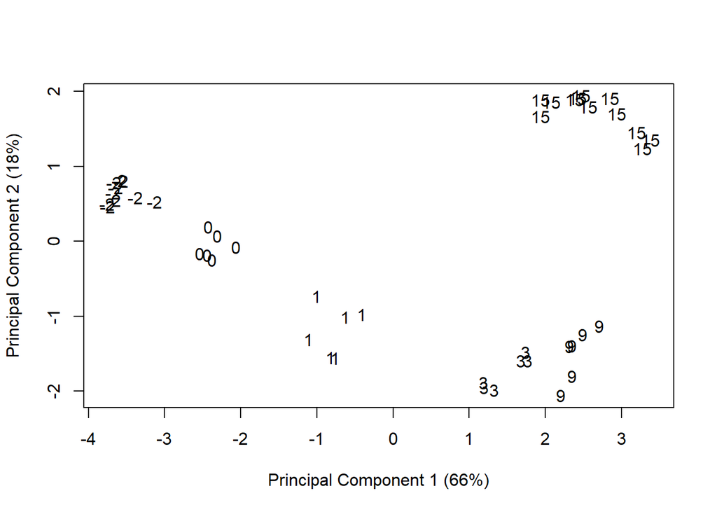

```r
plotMDS(whole_ob, labels = whole_ob$samples$time, gene.selection = "common")
```

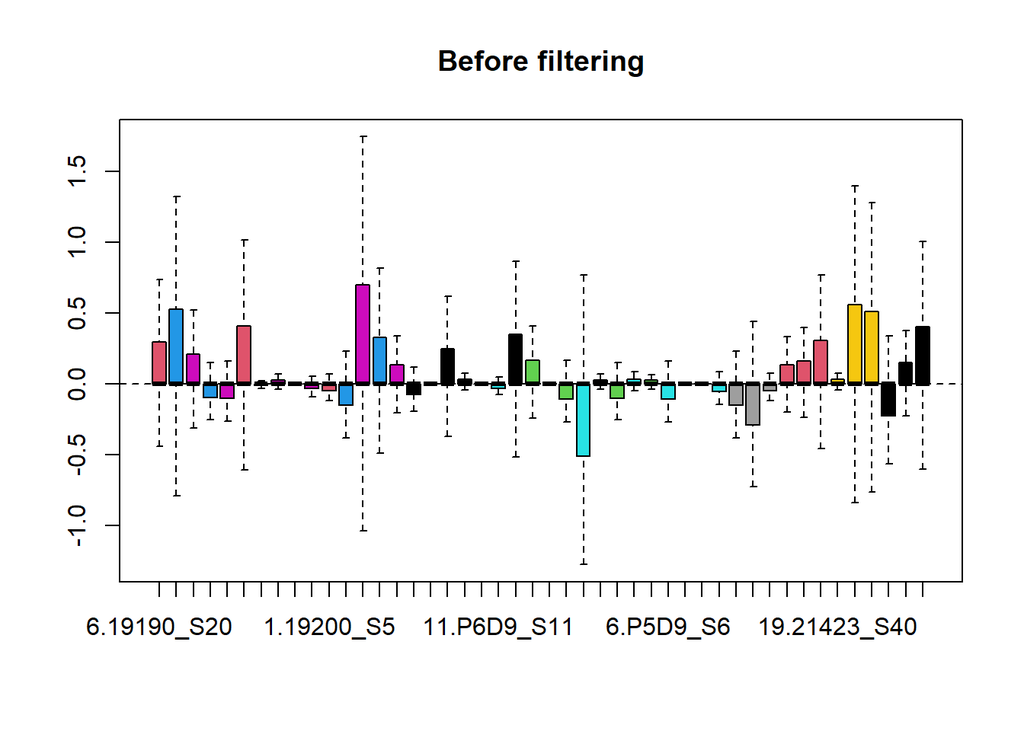

```r
plotRLE(whole_ob$counts, outline=FALSE, col=whole_ob$samples$group, main="Before filtering")
```

## Filtering

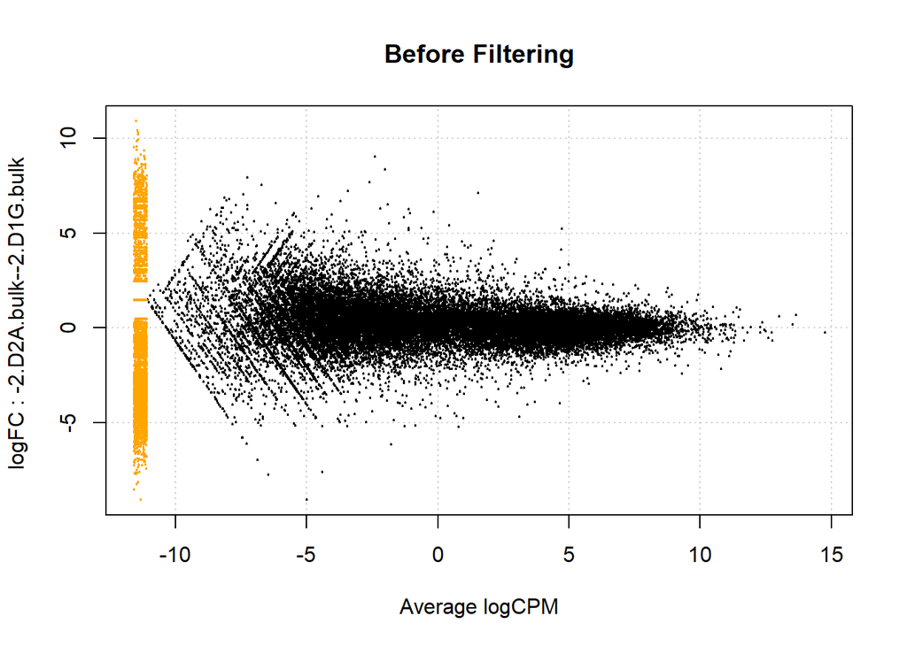

```r
plotSmear(whole_ob, main = "Before Filtering")
```

```r
dim(whole_ob)
```

```
## [1] 58735    46
```

```r
filt_series = whole_ob[filterByExpr(whole_ob),, keep.lib.sizes=FALSE]
dim(filt_series) #21174 genes kept (about 1k more genes that the timecourse to day9)
```

```
## [1] 21174    46
```

```r
#The filter is approxiamtely 10/ libsize in millions
10/(median(whole_ob$samples$lib.size)/1000000) #0.245 minimum CPM
```

```
## [1] 0.2447707
```

```r
#sanity check that gene_names match up
filt_series$counts[filt_series$genes$Geneid == "ENSG00000228630",] #HOTAIR
```

```
##      6.19190_S20       7.19191_S1       8.19192_S3       9.19193_S6
##            67.00            60.00            61.00            26.00
##      10.19194_S9     11.19195_S12     12.19196_S15     13.19197_S18
##            18.00            39.00            52.00            36.00
##     14.19198_S21      15.19199_S2       1.19200_S5       2.19201_S8
##            41.00            15.00            18.00            46.00
##      3.19202_S11      4.19203_S14      5.19204_S17  20.S2.KD5NT_S16
##           105.00            37.00            12.00           200.00
##  21.S7.KD6NT_S19 22.S12.KD3NT_S22       1.KD4NT_S1      10.P6D3_S10
##           251.90           313.00           276.00           325.00
##      11.P6D9_S11     12.KD3NT_S12      13.P8D0_S13      14.P8D1_S14
##            96.00           427.00           770.25           462.00
##      15.P8D3_S15      16.P8D9_S16       2.KD5NT_S2        3.P5D0_S3
##           237.00           106.00           196.00           375.00
##        4.P5D1_S4        5.P5D3_S5        6.P5D9_S6       7.KD6NT_S7
##           454.00           438.00           151.00           342.00
##        8.P6D0_S8        9.P6D1_S9     13.21417_S53      14.21418_S2
##           595.00           330.00            71.00            41.00
##      15.21419_S9     16.21420_S16     17.21421_S24     18.21422_S32
##            71.00            26.00            11.00            15.00
##     19.21423_S40     20.21424_S47     21.21425_S54      22.21426_S3
##           339.00           797.12           844.00            26.00
##     23.21427_S10     24.21428_S17
##            78.00            47.00
```

```r
filt_series$counts[filt_series$genes$Geneid == "ENSG00000132170",] #PPARG
```

```
##      6.19190_S20       7.19191_S1       8.19192_S3       9.19193_S6
##          1303.10          1667.00          3994.00          6675.10
##      10.19194_S9     11.19195_S12     12.19196_S15     13.19197_S18
##          7365.24          1319.10           557.12          3194.31
##     14.19198_S21      15.19199_S2       1.19200_S5       2.19201_S8
##          7950.67          9278.10           542.00           671.00
##      3.19202_S11      4.19203_S14      5.19204_S17  20.S2.KD5NT_S16
##          4561.33          8161.83         11953.80           392.20
##  21.S7.KD6NT_S19 22.S12.KD3NT_S22       1.KD4NT_S1      10.P6D3_S10
##          1183.37          1248.50           743.00          3307.83
##      11.P6D9_S11     12.KD3NT_S12      13.P8D0_S13      14.P8D1_S14
##          5122.53           976.17           645.00          1255.00
##      15.P8D3_S15      16.P8D9_S16       2.KD5NT_S2        3.P5D0_S3
##          3011.50          3613.41           537.00           262.00
##        4.P5D1_S4        5.P5D3_S5        6.P5D9_S6       7.KD6NT_S7
##           886.00          3387.60          6195.75           793.00
##        8.P6D0_S8        9.P6D1_S9     13.21417_S53      14.21418_S2
##           537.10          1261.10         20687.05         21560.08
##      15.21419_S9     16.21420_S16     17.21421_S24     18.21422_S32
##         19293.64         30703.87         32751.01         38751.89
##     19.21423_S40     20.21424_S47     21.21425_S54      22.21426_S3
##         10886.47         12895.56         13914.89          8218.48
##     23.21427_S10     24.21428_S17
##         16600.64         18475.29
```

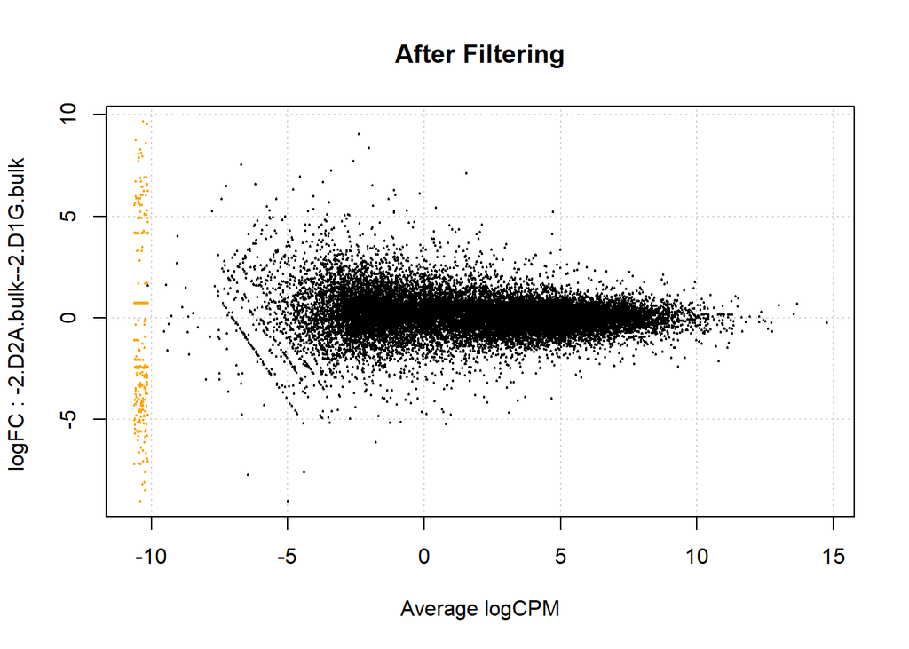

```r
plotSmear(filt_series, main = "After Filtering")
```

Donor vs donor this looks like very nice filtering (above, at any one time point some genes will be missing).

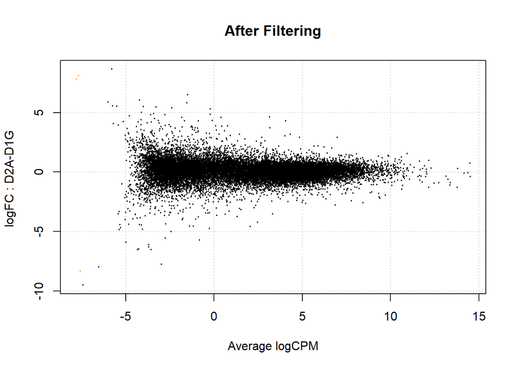

```r
#Plot donor v donor -> a few low exression genes still but predominantly good filtering
two_filt = filt_series
two_filt$samples$group = as.factor(filt_series$samples$donor)
plotSmear(two_filt, main = "After Filtering")
```

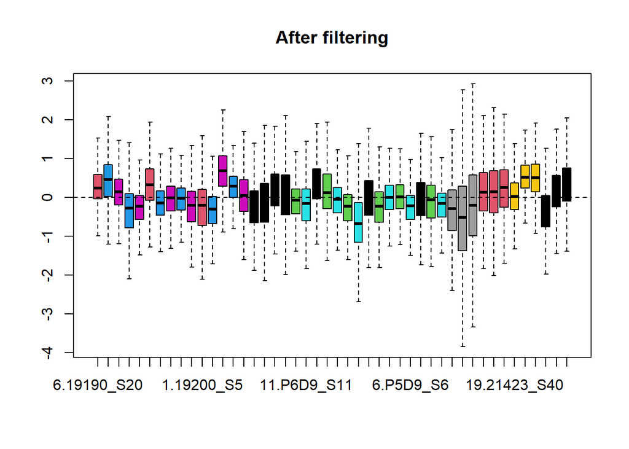

```r
#library sizes are different, but relative log expression is
#now ~ normally distributed within libraries
plotRLE(filt_series$counts, outline=FALSE,
        col=filt_series$samples$group, main="After filtering")
```

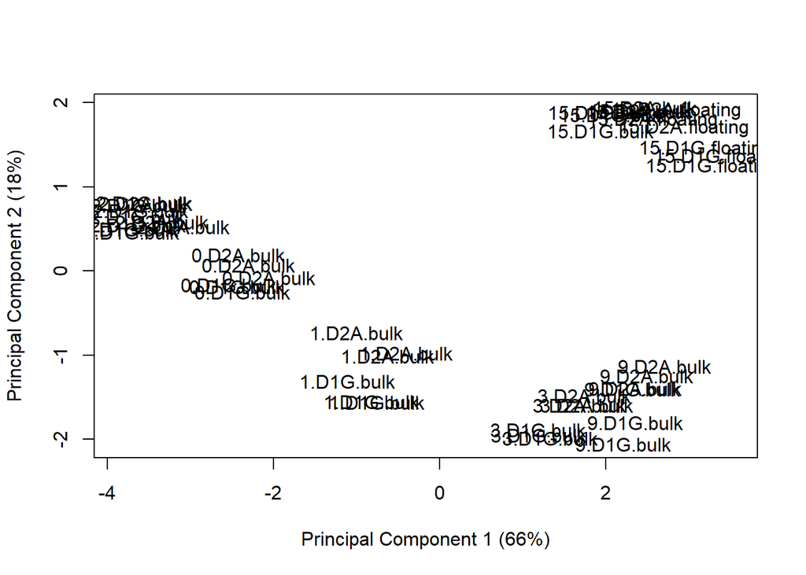

```r
plotMDS(filt_series, labels = filt_series$samples$group, gene.selection = "common")
```

Because we’re mainly interested in days Pro,0, 3 and 15 (bulk) I’m going to create a filter vector that eliminates genes that would drop out if we only used those samples. The limma voom method requires adequate filtering of low counts genes to maintain conservative p-values.

```r
short_ob = whole_ob[, whole_ob$samples$time %in% c(-2,0,3,15) &
                       whole_ob$samples$separation == "bulk"]
short_ob$samples
```

```
##                        group lib.size norm.factors        sample_id time donor
## 6.19190_S20      -2.D2A.bulk 43343287            1      6.19190_S20   -2   D2A
## 7.19191_S1        0.D2A.bulk 53954862            1       7.19191_S1    0   D2A
## 9.19193_S6        3.D2A.bulk 27650074            1       9.19193_S6    3   D2A
## 11.19195_S12     -2.D2A.bulk 44069380            1     11.19195_S12   -2   D2A
## 12.19196_S15      0.D2A.bulk 33748947            1     12.19196_S15    0   D2A
## 14.19198_S21      3.D2A.bulk 38990845            1     14.19198_S21    3   D2A
## 1.19200_S5       -2.D2A.bulk 24715231            1       1.19200_S5   -2   D2A
## 2.19201_S8        0.D2A.bulk 25887790            1       2.19201_S8    0   D2A
## 4.19203_S14       3.D2A.bulk 51335376            1      4.19203_S14    3   D2A
## 20.S2.KD5NT_S16  -2.D1G.bulk 28227567            1  20.S2.KD5NT_S16   -2   D1G
## 21.S7.KD6NT_S19  -2.D1G.bulk 30639099            1  21.S7.KD6NT_S19   -2   D1G
## 22.S12.KD3NT_S22 -2.D1G.bulk 39314312            1 22.S12.KD3NT_S22   -2   D1G
## 1.KD4NT_S1       -2.D1G.bulk 40875335            1       1.KD4NT_S1   -2   D1G
## 10.P6D3_S10       3.D1G.bulk 37487858            1      10.P6D3_S10    3   D1G
## 12.KD3NT_S12     -2.D1G.bulk 52250725            1     12.KD3NT_S12   -2   D1G
## 13.P8D0_S13       0.D1G.bulk 50473193            1      13.P8D0_S13    0   D1G
## 15.P8D3_S15       3.D1G.bulk 36821008            1      15.P8D3_S15    3   D1G
## 2.KD5NT_S2       -2.D1G.bulk 39256967            1       2.KD5NT_S2   -2   D1G
## 3.P5D0_S3         0.D1G.bulk 35885732            1        3.P5D0_S3    0   D1G
## 5.P5D3_S5         3.D1G.bulk 45252924            1        5.P5D3_S5    3   D1G
## 7.KD6NT_S7       -2.D1G.bulk 37829067            1       7.KD6NT_S7   -2   D1G
## 8.P6D0_S8         0.D1G.bulk 38988386            1        8.P6D0_S8    0   D1G
## 19.21423_S40     15.D1G.bulk 43513597            1     19.21423_S40   15   D1G
## 20.21424_S47     15.D1G.bulk 68529570            1     20.21424_S47   15   D1G
## 21.21425_S54     15.D1G.bulk 67338531            1     21.21425_S54   15   D1G
## 22.21426_S3      15.D2A.bulk 28524813            1      22.21426_S3   15   D2A
## 23.21427_S10     15.D2A.bulk 51405957            1     23.21427_S10   15   D2A
## 24.21428_S17     15.D2A.bulk 52000236            1     24.21428_S17   15   D2A
##                  biorep exp separation time.donor
## 6.19190_S20           7   2       bulk     -2.D2A
## 7.19191_S1            7   2       bulk      0.D2A
## 9.19193_S6            7   2       bulk      3.D2A
## 11.19195_S12          8   2       bulk     -2.D2A
## 12.19196_S15          8   2       bulk      0.D2A
## 14.19198_S21          8   2       bulk      3.D2A
## 1.19200_S5            5   2       bulk     -2.D2A
## 2.19201_S8            5   2       bulk      0.D2A
## 4.19203_S14           5   2       bulk      3.D2A
## 20.S2.KD5NT_S16       5   2       bulk     -2.D1G
## 21.S7.KD6NT_S19       6   2       bulk     -2.D1G
## 22.S12.KD3NT_S22      8   2       bulk     -2.D1G
## 1.KD4NT_S1           P4   1       bulk     -2.D1G
## 10.P6D3_S10          P6   1       bulk      3.D1G
## 12.KD3NT_S12         P8   1       bulk     -2.D1G
## 13.P8D0_S13          P8   1       bulk      0.D1G
## 15.P8D3_S15          P8   1       bulk      3.D1G
## 2.KD5NT_S2           P5   1       bulk     -2.D1G
## 3.P5D0_S3            P5   1       bulk      0.D1G
## 5.P5D3_S5            P5   1       bulk      3.D1G
## 7.KD6NT_S7           P6   1       bulk     -2.D1G
## 8.P6D0_S8            P6   1       bulk      0.D1G
## 19.21423_S40         P7   3       bulk     15.D1G
## 20.21424_S47       P8_2   3       bulk     15.D1G
## 21.21425_S54       P8_1   3       bulk     15.D1G
## 22.21426_S3          P7   3       bulk     15.D2A
## 23.21427_S10         P6   3       bulk     15.D2A
## 24.21428_S17         P7   3       bulk     15.D2A
```

```r
strict_filt_genes = short_ob[filterByExpr(short_ob),, keep.lib.sizes=FALSE]$genes
nrow(strict_filt_genes)
```

```
## [1] 20294
```

## Normalise

```r
filt_series = calcNormFactors(filt_series,method = "TMM")
filt_series$samples$norm.factors
```

```
##  [1] 1.2453947 1.2143844 1.1251937 1.1279176 0.9458378 1.3221153 1.0006515
##  [8] 1.1403659 0.9928395 1.0445354 1.3664816 1.1431881 1.2621641 1.0546869
## [15] 1.0419248 1.2097142 1.3116360 1.2920292 1.1244045 0.9951992 0.7803828
## [22] 1.1123288 0.9314547 1.0344064 0.8685081 0.8944916 1.1077081 0.8561931
## [29] 0.9462953 0.9419874 0.8237669 1.1048697 0.9583928 0.8541696 0.7900846
## [36] 0.6108555 0.6834306 0.8374520 0.7701180 0.8412588 0.9839876 1.0048101
## [43] 1.0123225 0.9974551 0.9286849 1.0430259
```

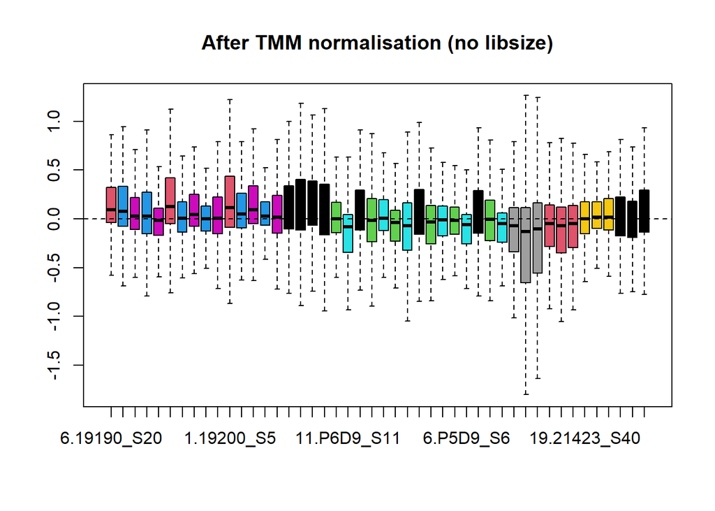

```r
plotRLE(cpm(filt_series$counts), outline=FALSE,
        col=filt_series$samples$group, main="After TMM normalisation (no libsize)")
```

Library size is approximately the same after CPM normalisation, but it still needs to be adjusted directly for library size:

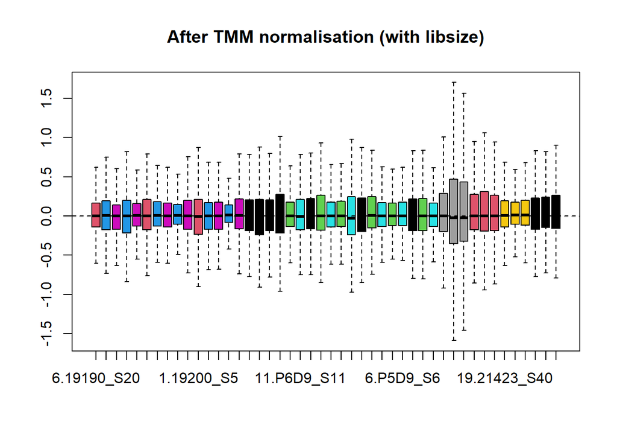

```r
plotRLE(cpm(filt_series, normalized.lib.sizes = TRUE), outline=FALSE,
        col=filt_series$samples$group, main="After TMM normalisation (with libsize)")
```

## Annotate Gene Lists

```r
library(biomaRt)
mart <- biomaRt::useMart(biomart = "ensembl",
  dataset = "hsapiens_gene_ensembl",
   host = "https://jan2019.archive.ensembl.org")
annot = getBM(c("external_gene_name", "description", "ensembl_gene_id"),
              filters = "ensembl_gene_id",
              values = filt_series$genes$Geneid,
              mart = mart)

head(annot, n=2); dim(annot)
```

```
##   external_gene_name                                       description
## 1             TSPAN6 tetraspanin 6 [Source:HGNC Symbol;Acc:HGNC:11858]
## 2               TNMD   tenomodulin [Source:HGNC Symbol;Acc:HGNC:17757]
##   ensembl_gene_id
## 1 ENSG00000000003
## 2 ENSG00000000005
```

```
## [1] 21174     3
```

```r
#Tidying up the annot table
annot$description = gsub("\\[Source:.+\\]", "", annot$description)
colnames(annot)[1] = "gene_name"

#Add gene names to filt_series
filt_series$genes = merge(filt_series$genes, annot, by.x= "Geneid",
                        by.y = "ensembl_gene_id", sort=FALSE)
#head(filt_series$genes)
#make sure length is numeric
filt_series$genes$Length = as.numeric(filt_series$genes$Length)
```

## Calculate FPKM

```r
rpkm = as.data.frame(rpkm(filt_series, normalized.lib.sizes = T))
rpkm$gene = rownames(rpkm)
colnames(rpkm) = paste("day",filt_series$samples$group, "_rep",filt_series$samples$biorep, sep="")
head(rpkm)
```

```
##                 day-2.D2A.bulk_rep7 day0.D2A.bulk_rep7 day1.D2A.bulk_rep7
## ENSG00000000003            4.429771        8.156323470         4.38952419
## ENSG00000000005            0.000000        0.009483402         0.04928463
## ENSG00000000419           44.399215       35.471356378        41.58979026
## ENSG00000000457            1.238538        2.004196996         1.73642745
## ENSG00000000460            1.180203        0.616667448         0.79787079
## ENSG00000000938            0.037342        0.039555121         0.06281165
##                 day3.D2A.bulk_rep7 day9.D2A.bulk_rep7 day-2.D2A.bulk_rep8
## ENSG00000000003         10.6804534          6.3980668         6.801005854
## ENSG00000000005          0.0597703          1.3456444         0.000000000
## ENSG00000000419         43.5042255         52.6514494        45.991978584
## ENSG00000000457          2.1702937          1.8297088         1.295959535
## ENSG00000000460          0.6343311          0.5946063         2.466087279
## ENSG00000000938          0.1200338          0.2892193         0.004942582
##                 day0.D2A.bulk_rep8 day1.D2A.bulk_rep8 day3.D2A.bulk_rep8
## ENSG00000000003         5.34283930         8.97825018         6.20967066
## ENSG00000000005         0.00000000         0.01544879         0.03209898
## ENSG00000000419        39.33891270        49.48751378        50.78492239
## ENSG00000000457         1.57592908         1.85270325         1.76943419
## ENSG00000000460         0.52619404         0.65859945         0.48500820
## ENSG00000000938         0.02557923         0.03579814         0.20826453
##                 day9.D2A.bulk_rep8 day-2.D2A.bulk_rep5 day0.D2A.bulk_rep5
## ENSG00000000003         10.8402147          9.06770306         5.32941019
## ENSG00000000005          2.4098978          0.00000000         0.08398167
## ENSG00000000419         42.9456144         33.13432809        39.93582431
## ENSG00000000457          2.0765218          1.48149383         1.92021291
## ENSG00000000460          0.6567233          1.30065327         0.54949797
## ENSG00000000938          0.2264708          0.01705362         0.01946035
##                 day1.D2A.bulk_rep5 day3.D2A.bulk_rep5 day9.D2A.bulk_rep5
## ENSG00000000003         5.84949758          6.0114837          9.2254928
## ENSG00000000005         0.60139195          0.2409799          4.4756616
## ENSG00000000419        41.36207525         44.8663886         41.5605299
## ENSG00000000457         1.75979885          1.9199313          2.2089933
## ENSG00000000460         0.75463451          0.4644325          0.6545097
## ENSG00000000938         0.03693757          0.1435891          0.6182750
##                 day-2.D1G.bulk_rep5 day-2.D1G.bulk_rep6 day-2.D1G.bulk_rep8
## ENSG00000000003          2.91981053          7.24007579          6.04191622
## ENSG00000000005          0.01819565          0.03092287          0.00000000
## ENSG00000000419         53.71154817         39.44174826         45.42236856
## ENSG00000000457          1.02998553          1.53342908          1.72161788
```

[output cut: 71 more lines]

```
## ENSG00000000938              0.6481190              0.6652296
##                 day15.D2A.bulk_repP7 day15.D2A.bulk_repP6 day15.D2A.bulk_repP7
## ENSG00000000003            7.6205880             8.960145            8.4071871
## ENSG00000000005            1.8124435             2.368496            1.6611412
## ENSG00000000419           37.5163734            36.592366           34.4896434
## ENSG00000000457            1.7366544             1.826420            1.3572695
## ENSG00000000460            0.4360015             0.463495            0.4265672
## ENSG00000000938            1.5888471             2.374268            1.7839139
##                              NA
## ENSG00000000003 ENSG00000000003
## ENSG00000000005 ENSG00000000005
## ENSG00000000419 ENSG00000000419
## ENSG00000000457 ENSG00000000457
## ENSG00000000460 ENSG00000000460
## ENSG00000000938 ENSG00000000938
```

```r
rpkm = rpkm[order(colnames(rpkm))]

format_rpkm = merge(filt_series$genes, rpkm,
                    by.x="Geneid", by.y = 'row.names',sort=FALSE)
head(format_rpkm)
```

```
##            Geneid Length gene_name
## 1 ENSG00000000003   4535    TSPAN6
## 2 ENSG00000000005   1610      TNMD
## 3 ENSG00000000419   1207      DPM1
## 4 ENSG00000000457   6883     SCYL3
## 5 ENSG00000000460   5967  C1orf112
## 6 ENSG00000000938   3474       FGR
##                                                    description
## 1                                               tetraspanin 6
## 2                                                 tenomodulin
## 3 dolichyl-phosphate mannosyltransferase subunit 1, catalytic
## 4                                    SCY1 like pseudokinase 3
## 5                         chromosome 1 open reading frame 112
## 6              FGR proto-oncogene, Src family tyrosine kinase
##   day-2.D1G.bulk_rep5 day-2.D1G.bulk_rep6 day-2.D1G.bulk_rep8
```

[output cut: 104 more lines]

```r
write.table(format_rpkm, sep='\t', row.names = FALSE,quote = F,
            file="../03limma/adipogenesis_rpkm_tmm.tab")
```

```r
filt_series$samples$time.donor = filt_series$samples$group
filt_series$samples$group = factor(paste("day",filt_series$samples$group, sep=""))
group_rpkm = data.frame(rpkmByGroup(filt_series,normalize.lib.sizes=TRUE))

colSums(group_rpkm)
```

```
##     day.2.D1G.bulk     day.2.D2A.bulk      day0.D1G.bulk      day0.D2A.bulk
##           240021.2           217572.3           368588.3           259177.3
##      day1.D1G.bulk      day1.D2A.bulk     day15.D1G.bulk day15.D1G.floating
##           432303.4           263522.6           337702.1           624718.6
##     day15.D2A.bulk day15.D2A.floating      day3.D1G.bulk      day3.D2A.bulk
##           346766.4           464595.3           475628.3           327786.6
##      day9.D1G.bulk      day9.D2A.bulk
##           590691.7           339424.4
```

```r
format_grpkm = merge(filt_series$genes, group_rpkm,
                    by.x="Geneid", by.y = 'row.names',sort=FALSE)
head(format_grpkm)
```

```
##            Geneid Length gene_name
## 1 ENSG00000000003   4535    TSPAN6
## 2 ENSG00000000005   1610      TNMD
## 3 ENSG00000000419   1207      DPM1
## 4 ENSG00000000457   6883     SCYL3
## 5 ENSG00000000460   5967  C1orf112
## 6 ENSG00000000938   3474       FGR
##                                                    description day.2.D1G.bulk
## 1                                               tetraspanin 6     3.601999275
## 2                                                 tenomodulin     0.007936845
## 3 dolichyl-phosphate mannosyltransferase subunit 1, catalytic    62.130005013
## 4                                    SCY1 like pseudokinase 3     1.426204636
## 5                         chromosome 1 open reading frame 112     1.906747475
## 6              FGR proto-oncogene, Src family tyrosine kinase     0.005503088
##   day.2.D2A.bulk day0.D1G.bulk day0.D2A.bulk day1.D1G.bulk day1.D2A.bulk
```

[output cut: 20 more lines]

```r
rowMeans(format_grpkm[format_grpkm$gene_name == "PPARG",c(6:ncol(format_grpkm))])#expr matches the replicate table
```

```
##   5456
## 46.428
```

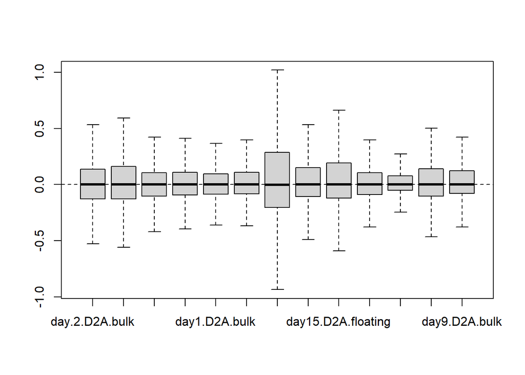

```r
plotRLE(data.matrix(format_grpkm[6:ncol(format_grpkm)]), outline=FALSE)
```

```r
write.table(format_grpkm, sep='\t', row.names = FALSE, quote=F,
            file="../03limma/adipogenesis_rpkm_tmm_means.tab")
```

## Limma Log Normalisation

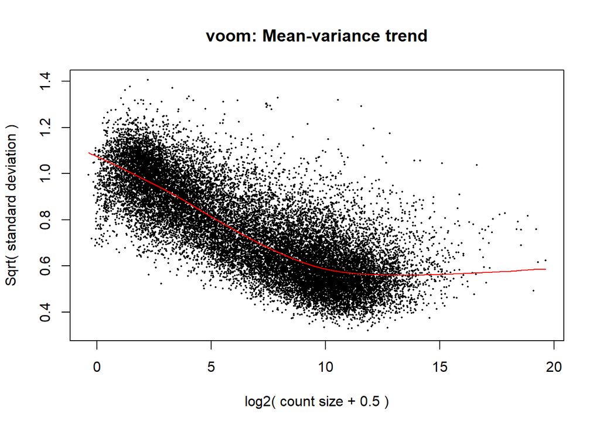

```r
filt_series$samples$group = filt_series$samples$time.donor
norm_series = voom(filt_series, plot = TRUE)
```

```r
head(norm_series$design, n=2) #groups are time.donor
```

```
##             (Intercept) group-2.D2A.bulk group0.D1G.bulk group0.D2A.bulk
## 6.19190_S20           1                1               0               0
## 7.19191_S1            1                0               0               1
##             group1.D1G.bulk group1.D2A.bulk group15.D1G.bulk
## 6.19190_S20               0               0                0
## 7.19191_S1                0               0                0
##             group15.D1G.floating group15.D2A.bulk group15.D2A.floating
## 6.19190_S20                    0                0                    0
## 7.19191_S1                     0                0                    0
##             group3.D1G.bulk group3.D2A.bulk group9.D1G.bulk group9.D2A.bulk
## 6.19190_S20               0               0               0               0
## 7.19191_S1                0               0               0               0
```

```r
summary(norm_series$E[,1])#log normlisation min -7, max 15
```

```
##    Min. 1st Qu.  Median    Mean 3rd Qu.    Max.
##  -6.754  -1.468   1.972   1.594   4.635  14.871
```

## Design

```r
#1 check the default design
colnames(norm_series$design)
```

```
##  [1] "(Intercept)"          "group-2.D2A.bulk"     "group0.D1G.bulk"
##  [4] "group0.D2A.bulk"      "group1.D1G.bulk"      "group1.D2A.bulk"
##  [7] "group15.D1G.bulk"     "group15.D1G.floating" "group15.D2A.bulk"
## [10] "group15.D2A.floating" "group3.D1G.bulk"      "group3.D2A.bulk"
## [13] "group9.D1G.bulk"      "group9.D2A.bulk"
```

```r
head(filt_series$samples, n=2)
```

```
##                   group lib.size norm.factors   sample_id time donor biorep exp
## 6.19190_S20 -2.D2A.bulk 43327502     1.245395 6.19190_S20   -2   D2A      7   2
## 7.19191_S1   0.D2A.bulk 53932903     1.214384  7.19191_S1    0   D2A      7   2
##             separation  time.donor
## 6.19190_S20       bulk -2.D2A.bulk
## 7.19191_S1        bulk  0.D2A.bulk
```

```r
pair_design = model.matrix(~0+filt_series$samples$group)
colnames(pair_design) = paste("day", gsub("-",".",levels(filt_series$samples$group)), sep="")
rownames(pair_design) = filt_series$samples$sample_id
head(pair_design, n=2)
```

```
##             day.2.D1G.bulk day.2.D2A.bulk day0.D1G.bulk day0.D2A.bulk
## 6.19190_S20              0              1             0             0
## 7.19191_S1               0              0             0             1
##             day1.D1G.bulk day1.D2A.bulk day15.D1G.bulk day15.D1G.floating
## 6.19190_S20             0             0              0                  0
## 7.19191_S1              0             0              0                  0
##             day15.D2A.bulk day15.D2A.floating day3.D1G.bulk day3.D2A.bulk
## 6.19190_S20              0                  0             0             0
## 7.19191_S1               0                  0             0             0
##             day9.D1G.bulk day9.D2A.bulk
## 6.19190_S20             0             0
## 7.19191_S1              0             0
```

## Making a large time based model

Using bulk day15 samples time_effect_donor1 + time_effect_donor2 was the pvalue used at 0.01 to select genes for dpgp

```r
pair_fit = lmFit(norm_series, design=pair_design)

contrasts = makeContrasts(time_effect_donor1 = (day0.D1G.bulk - day.2.D1G.bulk ) + #D-2 -> D0 effect
                                                  (day1.D1G.bulk - day0.D1G.bulk) + #D0 -> D1 effect
                                                  (day3.D1G.bulk - day1.D1G.bulk) + #D1 -> D3 effect
                                                  (day9.D1G.bulk - day3.D1G.bulk) + #D3 -> D9 effect
                                                  (day15.D1G.bulk - day9.D1G.bulk),
                          time_effect_donor2 = (day0.D2A.bulk - day.2.D2A.bulk ) + #D-2 -> D0 effect
                                                  (day1.D2A.bulk - day0.D2A.bulk) + #D0 -> D1 effect
                                                  (day3.D2A.bulk - day1.D2A.bulk) + #D1 -> D3 effect
                                                  (day9.D2A.bulk - day3.D2A.bulk) + #D3 -> D9 effect
                                                  (day15.D2A.bulk - day9.D2A.bulk), #D9 -> D15 effect
                          simple_time_effect = (day0.D1G.bulk - day.2.D1G.bulk ) + #D-2 -> D0 effect
                                                  (day3.D1G.bulk - day0.D1G.bulk) + #D0 -> D3 effect
                                                  (day15.D1G.bulk - day3.D1G.bulk) + #D3 -> D15 effect
                                                  (day0.D2A.bulk - day.2.D2A.bulk ) + #D-2 -> D0 effect
                                                  (day3.D2A.bulk - day0.D2A.bulk) + #D1 -> D3 effect
                                                  (day15.D2A.bulk - day3.D2A.bulk), #D9 -> D15 effect
                          #Donor 7 changes over time
                          d.2_to_d0.D1 = day0.D1G.bulk - day.2.D1G.bulk,
                          d0_to_d1.D1 = day1.D1G.bulk - day0.D1G.bulk,
                          d1_to_d3.D1 = day3.D1G.bulk - day1.D1G.bulk,
                          d3_to_d9.D1= day9.D1G.bulk - day3.D1G.bulk,
                          d9_to_d15.D1.bulk =  day15.D1G.bulk - day9.D1G.bulk,
                          d9_to_d15.D1.floating =  day15.D1G.floating - day9.D1G.bulk,
                          d15.bulk_to_floating.D1 = day15.D1G.floating - day15.D1G.bulk,
                          #Donor 13 changes over time
                          d.2_to_d0.D2 = day0.D2A.bulk - day.2.D2A.bulk,
                          d0_to_d1.D2 = day1.D2A.bulk - day0.D2A.bulk,
                          d1_to_d3.D2 = day3.D2A.bulk - day1.D2A.bulk,
                          d3_to_d9.D2 = day9.D2A.bulk - day3.D2A.bulk,
                          d9_to_d15.D2.bulk =  day15.D2A.bulk - day9.D2A.bulk,
                          d9_to_d15.D2.floating =  day15.D2A.floating - day9.D2A.bulk,
                          d15.bulk_to_floating.D2 = day15.D2A.floating - day15.D2A.bulk,
                          #And the additional timepoints
                          d0_to_d3.D1 =  day3.D1G.bulk - day0.D1G.bulk,
                          d0_to_d3.D2 =  day3.D2A.bulk - day0.D2A.bulk,
                          d3_to_d15.D1 =  day15.D1G.bulk - day3.D1G.bulk,
                          d3_to_d15.D2 =  day15.D2A.bulk - day3.D2A.bulk,
                          levels=pair_design)
special_fit = contrasts.fit(pair_fit,contrasts)
special_fit = eBayes(special_fit, robust = TRUE)
```

```r
summary(decideTests(special_fit, method="separate", adjust.method = "BH", p.value = 0.01)) #Adjusted for contrast
```

```
##        time_effect_donor1 time_effect_donor2 simple_time_effect d.2_to_d0.D1
## Down                 4563               4558               5677         2489
## NotSig              11929              12246               9577        15507
## Up                   4682               4370               5920         3178
##        d0_to_d1.D1 d1_to_d3.D1 d3_to_d9.D1 d9_to_d15.D1.bulk
## Down          1437         250         319              3353
## NotSig       18900       20481       20466             14120
## Up             837         443         389              3701
##        d9_to_d15.D1.floating d15.bulk_to_floating.D1 d.2_to_d0.D2 d0_to_d1.D2
## Down                    4357                    3097          909        1301
## NotSig                 12264                   14860        19492       19021
## Up                      4553                    3217          773         852
##        d1_to_d3.D2 d3_to_d9.D2 d9_to_d15.D2.bulk d9_to_d15.D2.floating
## Down           619         178              3067                  3181
## NotSig       19845       20687             15334                 14969
## Up             710         309              2773                  3024
##        d15.bulk_to_floating.D2 d0_to_d3.D1 d0_to_d3.D2 d3_to_d15.D1
## Down                       131        2275        2295         3626
## NotSig                   20871       17367       17103        13821
## Up                         172        1532        1776         3727
##        d3_to_d15.D2
## Down           3120
## NotSig        14923
## Up             3131
```

```r
summary(decideTests(special_fit ,method="global", adjust.method = "BH"), p.value= 0.01) #Unadjusted for contrast
```

```
##        time_effect_donor1 time_effect_donor2 simple_time_effect d.2_to_d0.D1
## Down                 5221               5396               6195         3493
## NotSig              10452              10500               8377        13338
## Up                   5501               5278               6602         4343
##        d0_to_d1.D1 d1_to_d3.D1 d3_to_d9.D1 d9_to_d15.D1.bulk
## Down          2548        1033        1461              4262
## NotSig       16874       19076       18477             12007
## Up            1752        1065        1236              4905
##        d9_to_d15.D1.floating d15.bulk_to_floating.D1 d.2_to_d0.D2 d0_to_d1.D2
## Down                    5132                    4255         1885        2463
## NotSig                 10613                   12584        17453       16828
## Up                      5429                    4335         1836        1883
##        d1_to_d3.D2 d3_to_d9.D2 d9_to_d15.D2.bulk d9_to_d15.D2.floating
## Down          1474         803              4022                  4019
## NotSig       18206       19266             13104                 12956
## Up            1494        1105              4048                  4199
##        d15.bulk_to_floating.D2 d0_to_d3.D1 d0_to_d3.D2 d3_to_d15.D1
## Down                       996        3335        3330         4642
## NotSig                   18822       15385       15140        11762
## Up                        1356        2454        2704         4770
##        d3_to_d15.D2
## Down           4135
## NotSig        12685
## Up             4354
```

Interesting, the time effect is less significant in donor2. The time effect is similar rather than different between donors -> most genes respond similarly to the adipogenic cocktail, regardless of depot/donor. Removing those extra timepoints (Day1, Day9), leads to ~6k genes found both up and down

## Number of DE genes

Adding an extra timepoint adds more genes to the DE list; 11,639 genes at p < 0.01 (basically 50% of all detected genes).

```r
comb = topTable(special_fit, number = nrow(pair_fit$genes), coef = c("time_effect_donor1","time_effect_donor2"))
dim(comb[comb$adj.P.Val < 0.05,]) #More than half of all genes change; most will be the same
```

```
## [1] 14236    10
```

```r
dim(comb[comb$adj.P.Val < 0.01,])
```

```
## [1] 11639    10
```

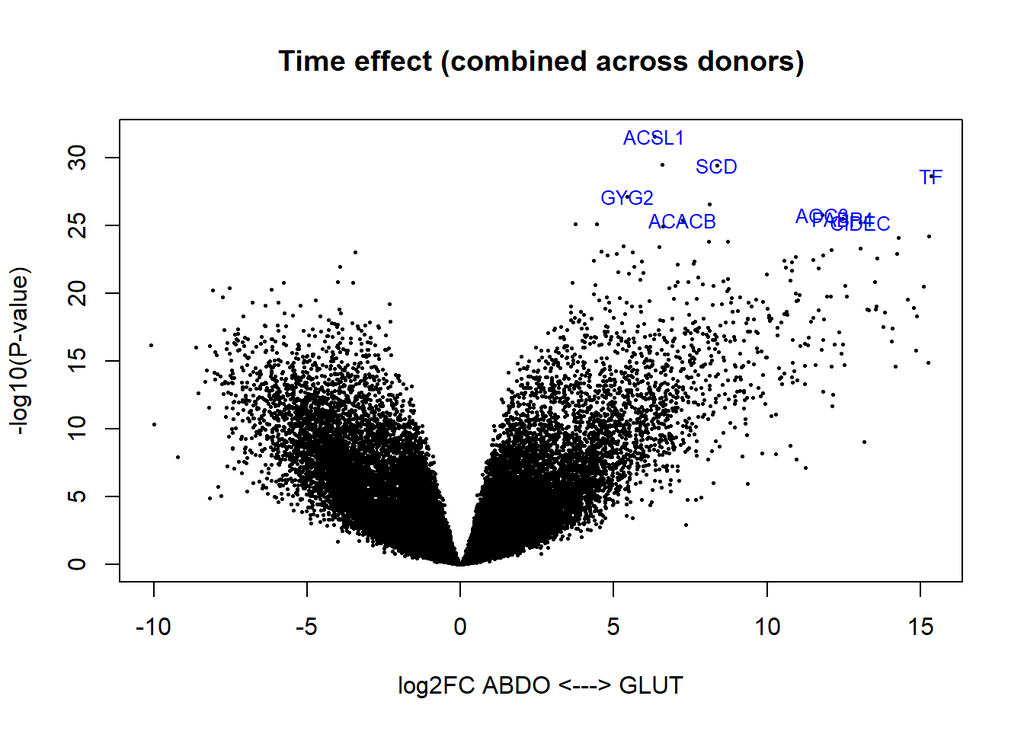

```r
volcanoplot(special_fit, coef = c(1,2), highlight =10, names = special_fit$genes$gene_name,
            main="Time effect (combined across donors)", xlab="log2FC ABDO <---> GLUT")
```

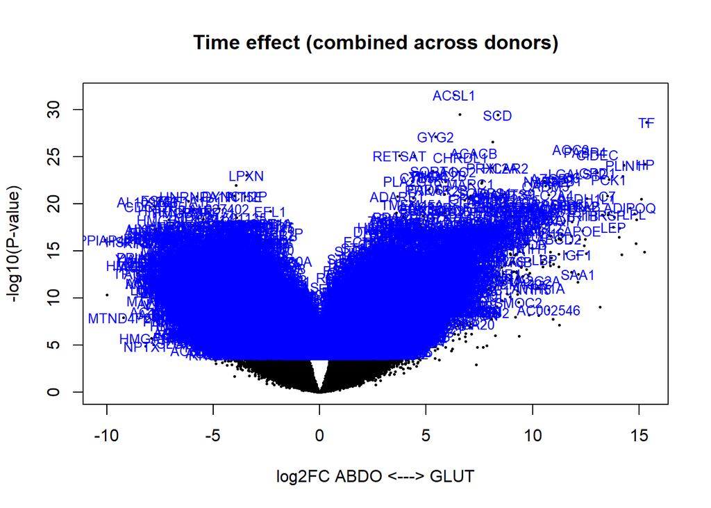

```r
volcanoplot(special_fit, coef = c(1,2), highlight =11639, names = special_fit$genes$gene_name,
            main="Time effect (combined across donors)", xlab="log2FC ABDO <---> GLUT")
```

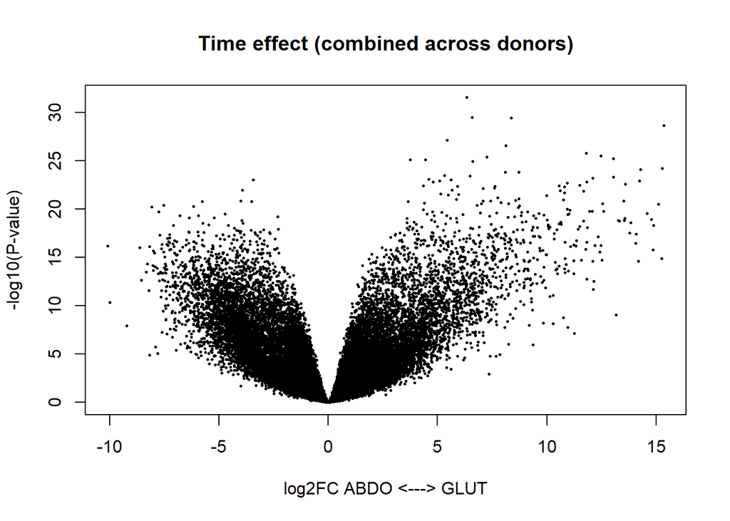

```r
volcanoplot(special_fit, coef = c(1,2),
            main="Time effect (combined across donors)", xlab="log2FC ABDO <---> GLUT")
```

```r
head(comb)
```

```
##                          Geneid Length gene_name
## ENSG00000151726 ENSG00000151726   6284     ACSL1
## ENSG00000099194 ENSG00000099194   5362       SCD
## ENSG00000091513 ENSG00000091513  26199        TF
## ENSG00000056998 ENSG00000056998   3655      GYG2
## ENSG00000042445 ENSG00000042445   4005    RETSAT
## ENSG00000131471 ENSG00000131471   4524      AOC3
##                                                     description
## ENSG00000151726 acyl-CoA synthetase long chain family member 1
## ENSG00000099194                        stearoyl-CoA desaturase
## ENSG00000091513                                    transferrin
## ENSG00000056998                                   glycogenin 2
## ENSG00000042445                               retinol saturase
## ENSG00000131471             amine oxidase, copper containing 3
##                 time_effect_donor1 time_effect_donor2   AveExpr         F
## ENSG00000151726           6.328527           6.587910  8.810891 1311.9493
## ENSG00000099194           8.374125           8.116002 11.807874  977.5091
## ENSG00000091513          15.353000          14.232266  3.105257  772.2546
## ENSG00000056998           5.435924           4.592658  4.980263  682.1097
## ENSG00000042445           3.744336           4.451633  7.100134  664.3586
## ENSG00000131471          11.794312          11.680727  6.379407  583.7300
##                      P.Value    adj.P.Val
## ENSG00000151726 4.270636e-36 9.042645e-32
## ENSG00000099194 1.366785e-33 1.447015e-29
## ENSG00000091513 1.130334e-31 7.977894e-28
## ENSG00000056998 9.522686e-31 5.040834e-27
## ENSG00000042445 1.558533e-30 6.600076e-27
## ENSG00000131471 2.068864e-29 6.793301e-26
```

```r
nuc = topTable(special_fit, number = nrow(pair_fit$genes), coef = "simple_time_effect")
dim(nuc[nuc$adj.P.Val < 0.05,]) #More than half of all genes change; most will be the same
```

```
## [1] 13727    10
```

```r
dim(nuc[nuc$adj.P.Val < 0.01,])
```

```
## [1] 11597    10
```

```r
nuc = nuc[nuc$Geneid %in% strict_filt_genes$Geneid,] #We can filter out ~450 genes with low expression but "significant" at these timepoints
nrow(nuc)
```

```
## [1] 20294
```

```r
head(nuc)
```

```
##                          Geneid Length gene_name
## ENSG00000151726 ENSG00000151726   6284     ACSL1
## ENSG00000099194 ENSG00000099194   5362       SCD
## ENSG00000042445 ENSG00000042445   4005    RETSAT
## ENSG00000056998 ENSG00000056998   3655      GYG2
## ENSG00000076555 ENSG00000076555  14505     ACACB
## ENSG00000101938 ENSG00000101938   3920    CHRDL1
##                                                     description     logFC
## ENSG00000151726 acyl-CoA synthetase long chain family member 1  12.916437
## ENSG00000099194                        stearoyl-CoA desaturase  16.490127
## ENSG00000042445                               retinol saturase   8.195969
## ENSG00000056998                                   glycogenin 2  10.028582
## ENSG00000076555                    acetyl-CoA carboxylase beta  14.871196
## ENSG00000101938                                 chordin like 1  14.207558
##                   AveExpr        t      P.Value    adj.P.Val        B
## ENSG00000151726  8.810891 50.67161 8.291877e-37 1.755722e-32 68.92770
## ENSG00000099194 11.807874 43.63744 2.897205e-34 3.067271e-30 64.45829
## ENSG00000042445  7.100134 36.32129 2.309287e-31 9.779370e-28 59.33478
## ENSG00000056998  4.980263 36.39842 2.133268e-31 9.779370e-28 58.59981
## ENSG00000076555  7.351638 33.29351 7.038353e-30 2.474282e-26 55.41491
## ENSG00000101938  5.954537 32.38451 1.960845e-29 4.613214e-26 54.48242
```

```r
write.table(nuc,  sep="\t", row.names=FALSE,
            file.path("../03limma/nucleolus_adipogenesis_DE.tab"))
```

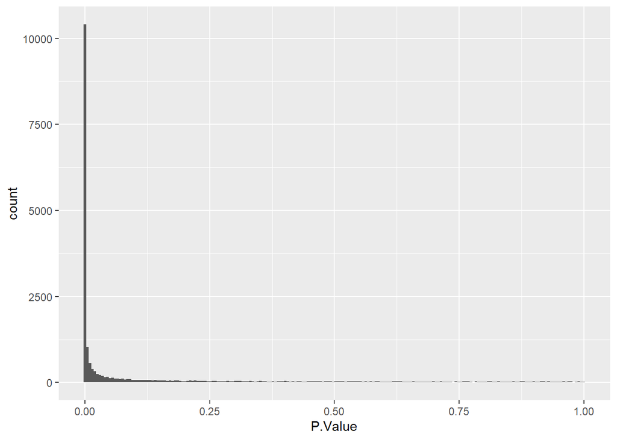

```r
ggplot(nuc) + geom_histogram(aes(x=P.Value), bins=200)
```

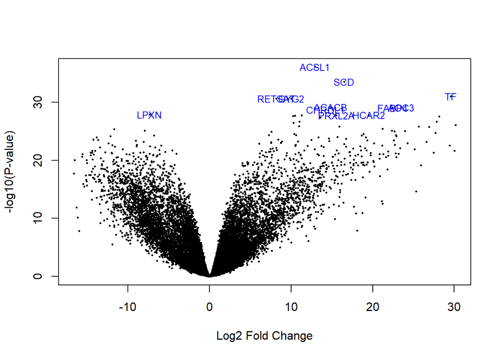

```r
volcanoplot(special_fit, coef="simple_time_effect", highlight = 12, names = special_fit$genes$gene_name)
```

## Venn diagram of new and old lists

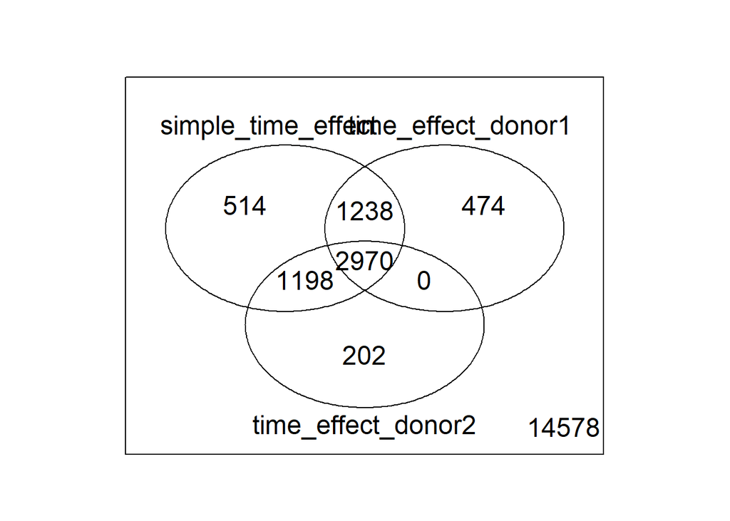

```r
res = decideTests(special_fit, method="separate", adjust.method = "BH", p.value = 0.01) #Adjusted for contrast

vennDiagram(res[,c("simple_time_effect","time_effect_donor1", "time_effect_donor2")], include="up")
```

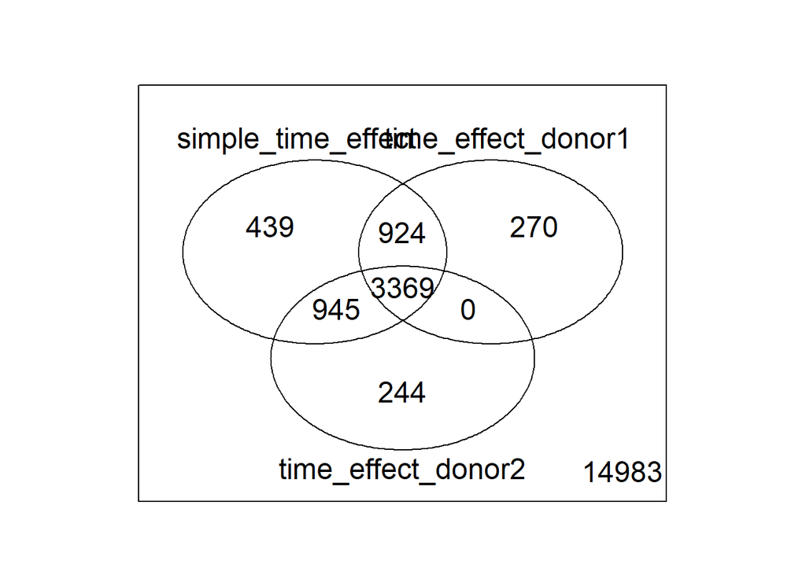

```r
vennDiagram(res[,c("simple_time_effect","time_effect_donor1", "time_effect_donor2")], include="down")
```

Okay, so there’s about 500 unique genes is either direction discovered by this test (as opposed to the d1->d3->d9 tests). We lose about the same number from either donor, but none that were in common between the donors, which seems promising. It seems that we capture the bulk of the adipogenic changes with just timepoints Pro, 0, 3 and 15 :)